# ETaxi Market Analysi

April 8th, 2019

## Lets' start

## Background

E-taxies are more and more important in people's daily choices of transportations. Not only for the convenience but also for the cheaper price and much better customer experience. Recently, lots of events come in front of public attention. Some of them are good, while some of them are bad. And for the safety of passengers, government and relevant companies publish some items and lists to control the quality of the E-taxies and drivers also. We have collected some data about different cities from respective government and companies.

## Data Description

- The datasets are collected from investigation about taxi markets.
- The datasets collected many features in different aspects, and many different cities. But because of lack of data, I selcect about 80 cities which contain all the feature in seperate data files.
- The variables are listed on the next page

## Data Description

```r
colnames(news)
```

```
##  [1] "文章序号"     "城市"         "文章发布时间" "关键词：专车"
##  [5] "软件"         "滴滴"         "网络约车"     "网约车"
##  [9] "黑车"         "文章标题"     "文章链接"     "文章内容"
```

```r
colnames(cond)
```

```
##  [1] "序号"         "省份"         "城市"         "车籍"
##  [5] "车型标准"     "轴距（mm）"   "续航里程"     "长宽高（mm）"
##  [9] "车价"         "车龄"         "行驶里程"     "排量"
## [13] "发动机功率"   "外观标识"     "保险"         "车载设备"
## [17] "...17"
```

## Data Description

- We notice that many data in the tables are in form of chinese characteristics. Thus necessary tools such as regular expression or segmentation workers to divide long texts into short words.
- Many features are not directly involved with what we want, how to convert into handleable is a small question for further analysis.
- Lots of NAs happened in the datasets, I delete some of them and fill some of them.

## Data Description

- Considering many categorical , it's more reasonable to measure or order them by some intuitive methods.
- I try to combine every feature together in avoid of losing any information useful for us.

## Goal of Our Analysis

There are mainly three goals as listed below.

- Find some factor proper enough to preserve the order or other information in the variable.
- Build a model to analyze articles published on wechat platform, and find out whether there is some main topic or pattern for the content.
- Build a model to cluster cities with similar feature and give the reasons why?

## Data preprocessiong

## Quantification

We convert distribution of amout of taxies into entropy which can stand for monopolization power in a specific market.

[figure not shown]

## WordCloud of the news articles.

- Firstly, we should find out what result our segmentation worker gives us.
- Display top key words in all the texts.

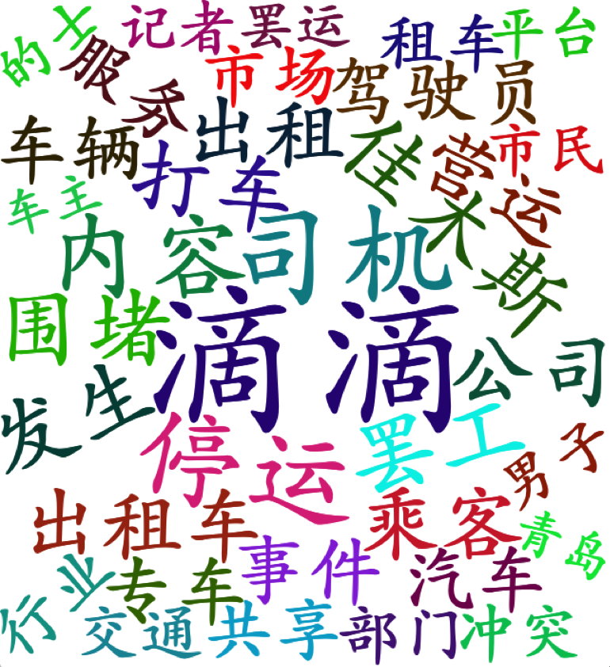

[figure not shown]

Some interesting pattern in big cities and small cities are obvious. Big cities have smaller entropy values than middle or small cities.

## LDA and topic model

Latent Dirichlet Allocation is a useful model for topic modeling. Here because of the complexity in computation, details of this model are in the report. I just main result here.

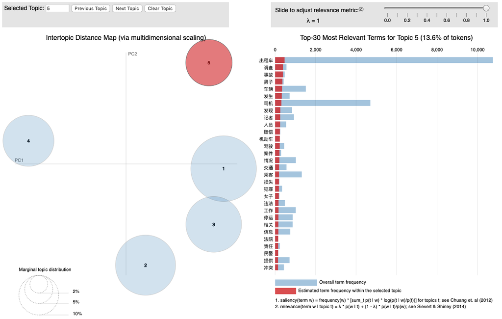

## Summary

## Conclusions

- Is there any obvious topics in all the articles?
- Is there any typical structure in cities?
- What is the suggestion can we get for cities in different clusters?

The conclusions and further improvements are served in the final report.